# RUV-seq on miRNA library

```r
library(UpSetR)
```

Prepare the data for analysis

```r
pdf(here::here("long_infection_human_reads/miRNA_library/results/final RUV figures/EDAseq_normalization.pdf"), width = 5, height = 5)
pData <- pData %>%
  mutate(graph_cols  = case_when(
    genotype == "UI" ~ carto_pal(12,pal_choice) [10],
    genotype == "WT" ~ carto_pal(12,pal_choice) [2],
    genotype == "N" ~ carto_pal(12,pal_choice) [1]
  ))
plotPCA(data, col = pData$graph_cols, main = "Unnormalized counts")
plotPCA(dataOffset, col = pData$graph_cols, main = "Normalized counts")
plotRLE(data, col = pData$graph_cols, main = "RLE Unnormalized counts")
plotRLE(dataOffset, col = pData$graph_cols, main = "RLE Normalized counts")
boxplot(data, main = "Unnormalized counts", col = pData$graph_cols)
boxplot(dataNorm, main = "Normalized counts", col = pData$graph_cols)
dev.off()
```

Try RUV-Seq. First confirm that library size normalization helps somewhat with data, but not enough for clear separation of genotypes

Prepare the RUV-seq objects and perform RUVs normalization

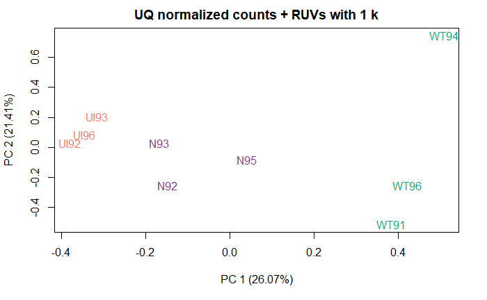

#The RUV normalization is done, now we have normalization factors or weights, that can be fed into DESeq2 Keep an eye on this https://bioconductor.org/packages/release/workflows/vignettes/rnaseqGene/inst/doc/rnaseqGene.html#using-ruv-with-deseq2

```r
dds <- DESeqDataSetFromMatrix(countData = counts(dataOffset),
                              colData = pData,
                              design = ~  group)
```

converting counts to integer mode

```r
normFactors <- exp(-1 * offst(dataOffset))
normFactors <- normFactors / exp(rowMeans(log(normFactors)))
normalizationFactors(dds) <- normFactors
dds <- DESeq(dds)
```

using pre-existing normalization factors estimating dispersions gene-wise dispersion estimates mean-dispersion relationship final dispersion estimates fitting model and testing

```r
rld <- varianceStabilizingTransformation(dds)
DESeq2::plotPCA(rld, intgroup = "group")
```

[output not shown]

```r
resWTvsUI <- results(dds, contrast = c("group","WT9", "UI9"))
resWTvsN <- results(dds, contrast = c("group","WT9", "N9"))
resNvsUI <- results(dds, contrast = c("group","N9", "UI9"))
walk(list(resWTvsUI,resWTvsN,resNvsUI),summary)
```

out of 626 with nonzero total read count adjusted p-value < 0.1 LFC > 0 (up) : 10, 1.6% LFC < 0 (down) : 6, 0.96% outliers [1] : 0, 0% low counts [2] : 0, 0% (mean count < 4) [1] see ‘cooksCutoff’ argument of ?results [2] see ‘independentFiltering’ argument of ?results

out of 626 with nonzero total read count adjusted p-value < 0.1 LFC > 0 (up) : 4, 0.64% LFC < 0 (down) : 0, 0% outliers [1] : 0, 0% low counts [2] : 0, 0% (mean count < 4) [1] see ‘cooksCutoff’ argument of ?results [2] see ‘independentFiltering’ argument of ?results

out of 626 with nonzero total read count adjusted p-value < 0.1 LFC > 0 (up) : 5, 0.8% LFC < 0 (down) : 5, 0.8% outliers [1] : 0, 0% low counts [2] : 0, 0% (mean count < 4) [1] see ‘cooksCutoff’ argument of ?results [2] see ‘independentFiltering’ argument of ?results

```r
dds1 <- DESeqDataSetFromMatrix(countData = counts(rv1),
                              colData = pData(rv1),
                              design = ~ W_1 + group)
```

converting counts to integer mode

```r
normFactors <- exp(-1 * offst(dataOffset))
normFactors <- normFactors / exp(rowMeans(log(normFactors)))
normalizationFactors(dds1) <- normFactors
dds1 <- DESeq(dds1)
```

using pre-existing normalization factors estimating dispersions gene-wise dispersion estimates mean-dispersion relationship final dispersion estimates fitting model and testing

```r
rld1 <- varianceStabilizingTransformation(dds1)
DESeq2::plotPCA(rld1, returnData = F, intgroup = "group")
```

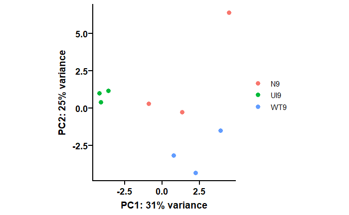

```r
mat <- limma::removeBatchEffect(assay(rld1),
                                covariates = rld1$W_1, design = model.matrix(~ genotype, colData(rld1)))
rld1.nobatch <- rld1
assay(rld1.nobatch) <- mat
DESeq2::plotPCA(rld1.nobatch, returnData = F, intgroup = "group")
```

[output not shown]

```r
resWTvsUI.1 <- results(dds1, contrast = c("group","WT9", "UI9"))
resWTvsN.1 <- results(dds1, contrast = c("group","WT9", "N9"))
resNvsUI.1 <- results(dds1, contrast = c("group","N9", "UI9"))
walk(list(resWTvsUI.1,resWTvsN.1,resNvsUI.1),summary)
```

out of 626 with nonzero total read count adjusted p-value < 0.1 LFC > 0 (up) : 14, 2.2% LFC < 0 (down) : 10, 1.6% outliers [1] : 0, 0% low counts [2] : 0, 0% (mean count < 4) [1] see ‘cooksCutoff’ argument of ?results [2] see ‘independentFiltering’ argument of ?results

out of 626 with nonzero total read count adjusted p-value < 0.1 LFC > 0 (up) : 4, 0.64% LFC < 0 (down) : 0, 0% outliers [1] : 0, 0% low counts [2] : 0, 0% (mean count < 4) [1] see ‘cooksCutoff’ argument of ?results [2] see ‘independentFiltering’ argument of ?results

out of 626 with nonzero total read count adjusted p-value < 0.1 LFC > 0 (up) : 6, 0.96% LFC < 0 (down) : 6, 0.96% outliers [1] : 0, 0% low counts [2] : 0, 0% (mean count < 4) [1] see ‘cooksCutoff’ argument of ?results [2] see ‘independentFiltering’ argument of ?results

```r
#Now repeat with 2 factors accounted for:
dds2 <- DESeqDataSetFromMatrix(countData = counts(rv2),
                              colData = pData(rv2),
                              design = ~ W_1 + W_2 + group)
```

converting counts to integer mode

```r
normalizationFactors(dds2) <- normFactors
dds2 <- DESeq(dds2)
```

using pre-existing normalization factors estimating dispersions gene-wise dispersion estimates mean-dispersion relationship final dispersion estimates fitting model and testing

```r
rld2 <- varianceStabilizingTransformation(dds2)
DESeq2::plotPCA(rld2, returnData = F, intgroup = "group")
```

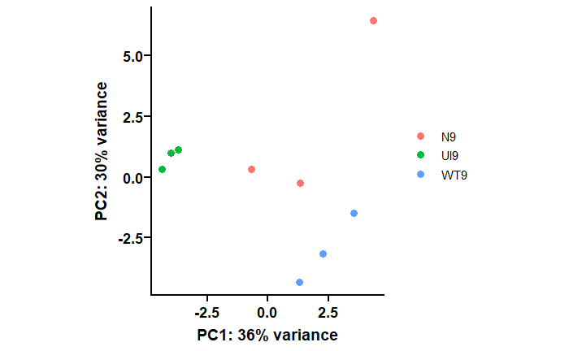

```r
mat <- limma::removeBatchEffect(assay(rld2),
                                covariates = matrix(data = c(rld2$W_1,rld2$W_2), ncol = 2),
                                design = model.matrix(~ genotype, colData(rld2)))
rld2.nobatch <- rld2
assay(rld2.nobatch) <- mat
DESeq2::plotPCA(rld2.nobatch, returnData = F, intgroup = "group")
```

[output not shown]

```r
resWTvsUI.2 <- results(dds2, contrast = c("group","WT9", "UI9"))
resWTvsN.2 <- results(dds2, contrast = c("group","WT9", "N9"))
resNvsUI.2 <- results(dds2, contrast = c("group","N9", "UI9"))
walk(list(resWTvsUI.2,resWTvsN.2,resNvsUI.2),summary)
```

out of 626 with nonzero total read count adjusted p-value < 0.1 LFC > 0 (up) : 10, 1.6% LFC < 0 (down) : 9, 1.4% outliers [1] : 0, 0% low counts [2] : 0, 0% (mean count < 4) [1] see ‘cooksCutoff’ argument of ?results [2] see ‘independentFiltering’ argument of ?results

out of 626 with nonzero total read count adjusted p-value < 0.1 LFC > 0 (up) : 3, 0.48% LFC < 0 (down) : 0, 0% outliers [1] : 0, 0% low counts [2] : 0, 0% (mean count < 4) [1] see ‘cooksCutoff’ argument of ?results [2] see ‘independentFiltering’ argument of ?results

out of 626 with nonzero total read count adjusted p-value < 0.1 LFC > 0 (up) : 6, 0.96% LFC < 0 (down) : 7, 1.1% outliers [1] : 0, 0% low counts [2] : 121, 19% (mean count < 10) [1] see ‘cooksCutoff’ argument of ?results [2] see ‘independentFiltering’ argument of ?results

Generally, the differences between 1 and 2 factors are not that large. Check how differentially expressed genes behave

```r
pdf(here::here("long_infection_human_reads/miRNA_library/results/final RUV figures/RUV effect on DE genes between WT and EscN infection.pdf"), width = 6, height = 5)
eulerplot <- euler(wtvsn.res, shape = "circle")
plot(eulerplot, quantities = list(T, type = c("counts"), fontsize = 12),
     fills = c(carto_pal(7,"BluYl") [1],carto_pal(7,"BluYl") [3], carto_pal(7,"BluYl") [7]),
     adjust_labels = T, alpha = 0.7, legend = T, labels = F)
upset(fromList(wtvsn.res))
dev.off()
```

Check correlation between PC and metadata with linear regressioin

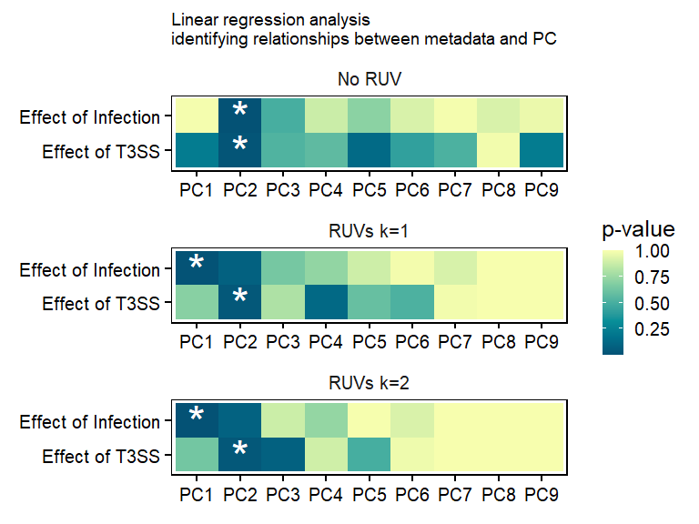

*Generally, does not seem like RUV can correct the data. So do not apply RUV to this library*